# Homework 4

## Differences after five years

In this section we will study the differences between the people who are either still alive or have died five years after the treatment. We set the evidence to either `alive` or `death` in the `FIVEYEARRESULT` node of the network. We can now directly observe the probabilities of the clinical stage, histological classification, bulky disease, and clinical representation. The age distribution cannot be observed. For this, we would need information about the treatment.

### Clinical stage

People that are still alive after five years are classified in less severe categories before the treatment. For example 53.2% of the alive people are classified in `cat I`, while only 44.3% of the death people are classified in that same category.

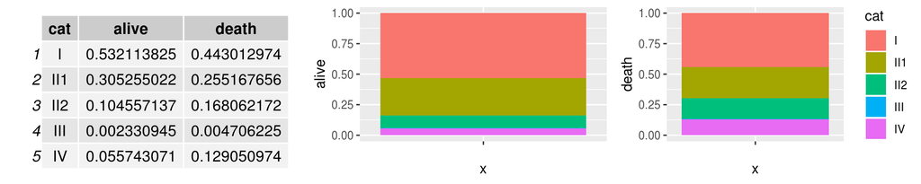

### Histological classification

For the histological classification we hardly observe a difference between the two groups.

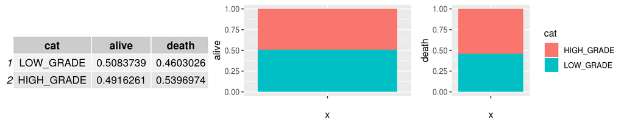

### Bulky Disease

People that survive after five years are less likely to have (had) a bulky disease. In fact, only 25% of the alive people was diagnosed with the bulky disease, while 32% of the death people had the bulky disease.

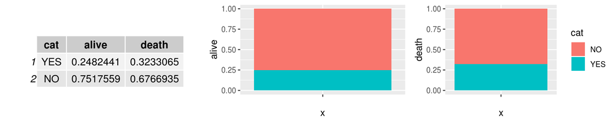

### Clinical presentation

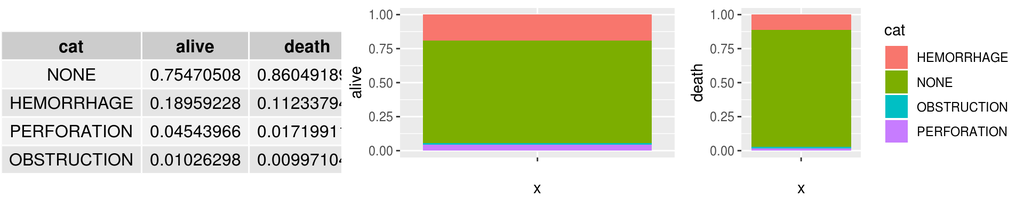

### General health status

The General Health Status differs mainly for POOR. Indeed, for the alive group, 23.5% of people have a poor general health status comparing the 9% for the death group.

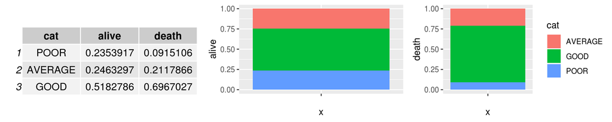

4.c)

In this section we study the different groups of people, based on age ranges. First we set the evidence of a single age range, then we group ranges that report the same value for the specific variable we are analyzing.

### Clinical stage

The first variable we take in consideration is `Clinical Stage`. We obtain 7 age range, as we can see in the graphs below.

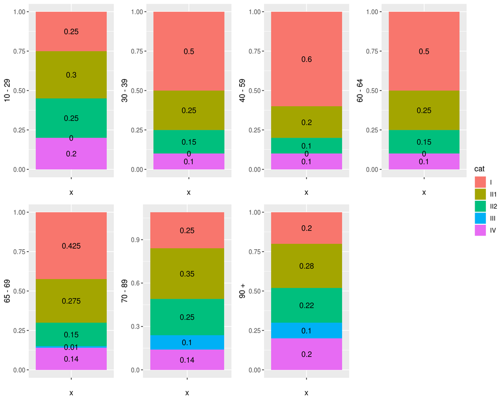

If we compare them to the graphs differentiating people by alive or dead after 5 years (`5YearsResult`), we can notice some similarities.

By visual inspection, we notice that age ranges `30-39, 40-59, 60-64` have a more similar distribution to the `alive` group, showing an higher probability to have `clinical stage` = `I` or `II1`.

As opposite, the first groups `10-29` and the group of people `65-69, 70-89, 90+`, show a behaviour more comparable to the group having `death` as `5YearsResult`, this is, having a lower probability to have `clinical stage` = `I` or `II1`, and an higher one to have `clinical stage` = `II2`, `III` or `IV`

### General health status

The second variable we take in consideration is `General health status`. We obtain 7 age range, as we can see in the graphs below.

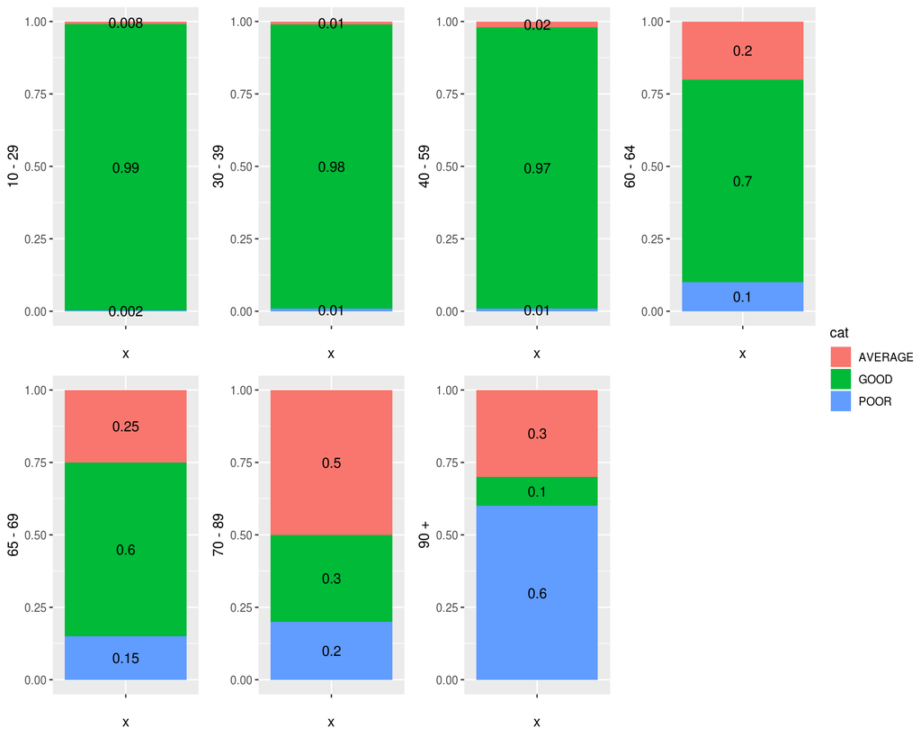

We can also see some similarities with the plots differentiating people by alive or dead after 5 years (`5YearsResult`).

By visual inspection, we notice that age ranges `10-29, 30-39, 40-59, 60-64, 65-69` show a higher probability to have `General Health Status` = `GOOD`.

This property seems to dicrease with the age.

Indeed, the last groups `70-89, 90+` show another behaviour with a the probability of `General Health Status` = `POOR` or `AVERAGE`getting higher.